# Survival_Workshop_Assignemnt

Elizabeth Sweeney

4/16/2019

```r
library(dplyr)
library(tableone)
library(survival)
library(survminer)
library(cmprsk)
```

[1] Open ‘dig.csv’ and read through the provided documentation ‘DIG Documentation with supplement.pdf’ to understand the data.

```r
dig <- read.csv("~/Desktop/digitalis/DIG_csv/DIG_csv/dig.csv")
```

[2] Do some exploratory analysis to get a handle on the data. This could take many forms, including a ‘table one’ for the treatment and non-treatment groups.

```r
dig$RACE  <- factor(dig$RACE,
                    levels = c("1", "2"),
                    labels = c("White", "Nonwhite"))

dig$SEX  <- factor(dig$SEX,
                    levels = c("1", "2"),
                    labels = c("Male", "Female"))


dig$CHFETIOL  <- factor(dig$CHFETIOL,
                        levels = c("1", "2", "3", "4", "5", "6"),
                        labels = c("Ischemic",
                                   "Hypertensive",
                                   "Valvular",
                                   "Idiopathic",
                                   "Alcohol Related",
                                   "Other"))


myVars <- c("AGE",
            "RACE",
            "SEX",
            "BMI",
            "CHFDUR",
            "NSYM",
            "CHFETIOL",
            "PREVMI",
            "ANGINA",
            "DIABETES",
            "HYPERTEN")

## Vector of categorical variables that need transformation
catVars <- c("RACE",
            "SEX",
            "CHFETIOL")

## Create a TableOne object
table1 <- CreateTableOne(strata =  'TRTMT', vars = myVars, data = dig, factorVars = catVars)


table1
```

```
##                       Stratified by TRTMT
##                        0             1             p      test
##   n                     3403          3397
##   AGE (mean (sd))      63.55 (10.81) 63.42 (11.02)  0.627
##   RACE = Nonwhite (%)    504 (14.8)    487 (14.3)   0.603
##   SEX = Female (%)       764 (22.5)    755 (22.2)   0.846
##   BMI (mean (sd))      27.23 (5.19)  27.00 (5.19)   0.079
##   CHFDUR (mean (sd))   29.80 (36.55) 30.52 (37.21)  0.422
##   NSYM (mean (sd))      3.67 (0.78)   3.65 (0.81)   0.328
##   CHFETIOL (%)                                      0.002
##      Ischemic           2398 (70.7)   2405 (71.0)
##      Hypertensive        311 ( 9.2)    272 ( 8.0)
##      Valvular             51 ( 1.5)     48 ( 1.4)
##      Idiopathic          482 (14.2)    525 (15.5)
##      Alcohol Related     130 ( 3.8)     92 ( 2.7)
##      Other                22 ( 0.6)     46 ( 1.4)
##   PREVMI (mean (sd))    0.65 (0.48)   0.65 (0.48)   0.639
##   ANGINA (mean (sd))    0.26 (0.44)   0.27 (0.44)   0.500
##   DIABETES (mean (sd))  0.29 (0.45)   0.28 (0.45)   0.803
##   HYPERTEN (mean (sd))  0.46 (0.50)   0.45 (0.50)   0.514
```

[3] Ignore the reason for death. Make Kaplan-Meier curves for the survival in the two treatment groups.

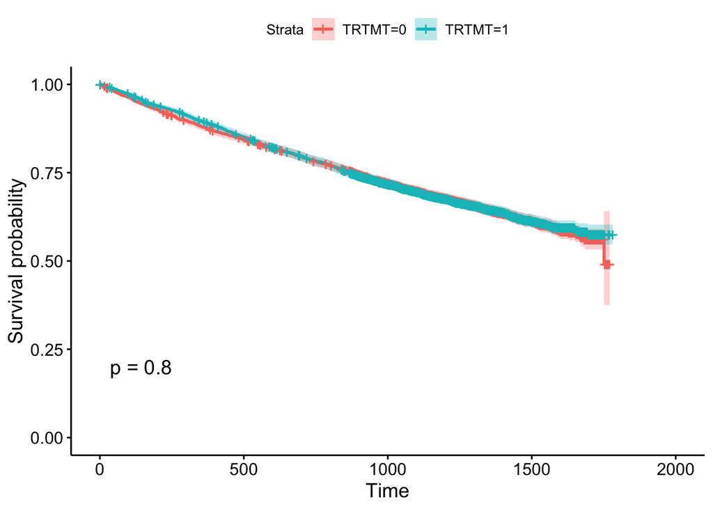

```r
surv_object_dig <- Surv(time = dig$DEATHDAY, event = dig$DEATH)

fit_dig_trtmt <-  survfit(surv_object_dig ~ TRTMT, data = dig)


ggsurvplot(fit_dig_trtmt,
           data = dig,
           pval = TRUE,
           conf.int = TRUE)
```

[4] Perform a statistical test to see if there is a difference between the two survival curves?

```r
survdiff(surv_object_dig ~ TRTMT, data = dig)
```

```
## Call:
## survdiff(formula = surv_object_dig ~ TRTMT, data = dig)
##
##            N Observed Expected (O-E)^2/E (O-E)^2/V
## TRTMT=0 3403     1194     1188    0.0316    0.0633
## TRTMT=1 3397     1181     1187    0.0317    0.0633
##
##  Chisq= 0.1  on 1 degrees of freedom, p= 0.8
```

[5] Fit a cox proportional hazards model to assess the difference between the two treatment groups adjust for other factors. Interpret your results.

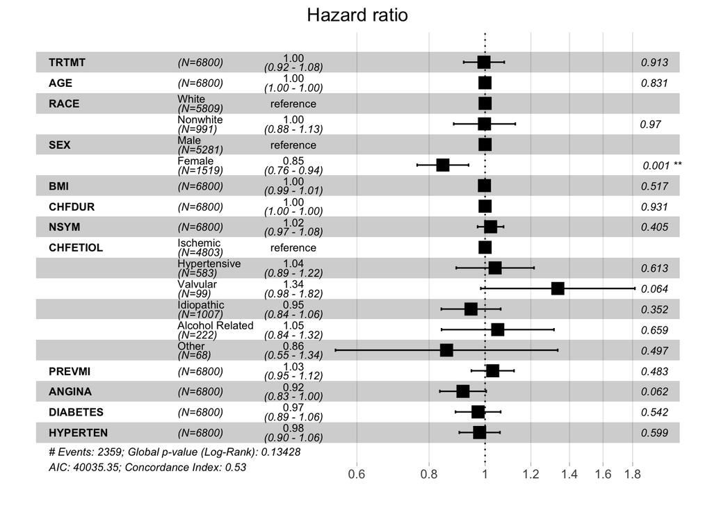

```r
fit.dig <- coxph(surv_object_dig ~ TRTMT +
                   AGE +
                   RACE +
                   SEX +
                   BMI +
                   CHFDUR +
                   NSYM +
                   CHFETIOL +
                   PREVMI +
                   ANGINA +
                   DIABETES +
                   HYPERTEN, data = dig)

ggforest(fit.dig, data = dig)
```

[6] Test the proportional hazards assumption in the model.

```r
zph.test.dig<- cox.zph(fit.dig)
```

[7] In this dataset we have competing risks. Death can be caused by worsening heart failure, other cardiac causes, other vascular causes, unknown or non cardiac and nonvascular causes. Investigate the cumulative incidence function for the different causes (note that for interpretability you may want to collapse some categories together).

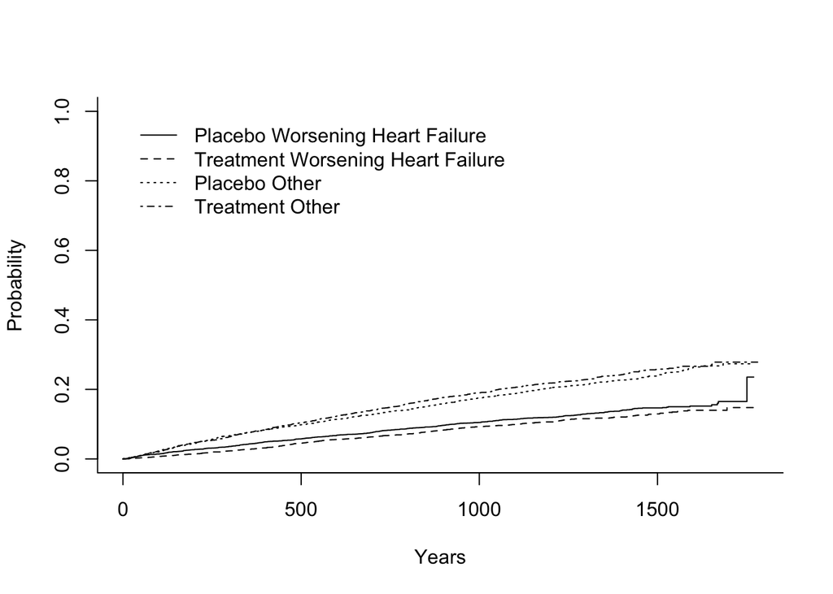

```r
dig$REASON[is.na(dig$REASON)] <- 0

dig$TRTMT  <- factor(dig$TRTMT,
                    levels = c("0", "1"),
                    labels = c("Placebo", "Treatment"))

dig$REASON  <- factor(dig$REASON,
                    levels = c("0", "1", "2", "3", "4", "5"),
                    labels = c("Censored",
                               "Worsening Heart Failure",
                               "Other Cardiac",
                               "Other Vascular",
                               "Unknown",
                               "Other Cause"))

levels(dig$REASON)[levels(dig$REASON) %in% c("Other Cardiac",
                                             "Other Vascular",
                                             "Unknown",
                                             "Other Cause")] <- "Other"



## Calculate the grouped cumulative incidence functions (CIF)
dig_cum_incidence <- cuminc(ftime   = dig$DEATHDAY,
                            fstatus = dig$REASON,
                            group   = dig$TRTMT,
                            cencode = "Censored")

plot(dig_cum_incidence)
```

[8] Fit a competing risk regression model to determine the treatment effect while adjusting for other confounders.

```r
dig.matrix <- dig %>%
 select(TRTMT, AGE, RACE, SEX, BMI, CHFDUR, NSYM, CHFETIOL, PREVMI, ANGINA, DIABETES, HYPERTEN)

dig.matrix <- data.matrix(dig.matrix)


bmt_crr_mortality <- crr(ftime = dig$DEATHDAY, # vector of failure/censoring times
                       fstatus  = dig$REASON, # vector with a unique code for each failure type and censoring
                       cov1     = dig.matrix, #  matrix (nobs x ncovs) of fixed covariates
                       failcode = "Worsening Heart Failure", # code of fstatus that denotes the failure type of interest
                       cencode  = "Censored" # code of fstatus that denotes censored observations
                       )
```

```
## 37 cases omitted due to missing values
```

```r
summary(bmt_crr_mortality)
```

```
## Competing Risks Regression
##
## Call:
## crr(ftime = dig$DEATHDAY, fstatus = dig$REASON, cov1 = dig.matrix,
##     failcode = "Worsening Heart Failure", cencode = "Censored")
##
##               coef exp(coef) se(coef)      z p-value
## TRTMT    -0.132567     0.876 0.069518 -1.907  0.0570
## AGE      -0.000538     0.999 0.003182 -0.169  0.8700
## RACE     -0.059446     0.942 0.101474 -0.586  0.5600
## SEX      -0.008604     0.991 0.084562 -0.102  0.9200
## BMI      -0.007905     0.992 0.007213 -1.096  0.2700
## CHFDUR   -0.001022     0.999 0.000971 -1.052  0.2900
## NSYM      0.101161     1.106 0.047782  2.117  0.0340
## CHFETIOL  0.011241     1.011 0.026681  0.421  0.6700
## PREVMI    0.098510     1.104 0.073582  1.339  0.1800
## ANGINA   -0.250437     0.778 0.082486 -3.036  0.0024
## DIABETES  0.051557     1.053 0.075657  0.681  0.5000
## HYPERTEN -0.046963     0.954 0.069527 -0.675  0.5000
##
##          exp(coef) exp(-coef)  2.5% 97.5%
## TRTMT        0.876      1.142 0.764 1.004
## AGE          0.999      1.001 0.993 1.006
## RACE         0.942      1.061 0.772 1.150
## SEX          0.991      1.009 0.840 1.170
## BMI          0.992      1.008 0.978 1.006
## CHFDUR       0.999      1.001 0.997 1.001
## NSYM         1.106      0.904 1.008 1.215
## CHFETIOL     1.011      0.989 0.960 1.066
## PREVMI       1.104      0.906 0.955 1.275
## ANGINA       0.778      1.285 0.662 0.915
## DIABETES     1.053      0.950 0.908 1.221
## HYPERTEN     0.954      1.048 0.833 1.093
##
## Num. cases = 6763 (37 cases omitted due to missing values)
## Pseudo Log-likelihood = -7196
## Pseudo likelihood ratio test = 23.6  on 12 df,
```